# Using Tweepy and NLTK to Analyze Tweets about Netflix #Punisher

In this Jupyter notebook, I intend to stream twitter data about The Punisher using Python's Tweepy library. I will then flatten the tweets, load them to Pandas, and analyze using techniques including, but not limited to, NLTK.

A few modules used are checked in to my GitHub page (flatten_tweets, slistener).

## 1. Setup and Stream Tweets

First, import libraries and setup matplotlib to run inline.

```python
%matplotlib inline

import json
import glob
import pandas as pd
import numpy as np
from tweepy import OAuthHandler, API, Stream
from slistener import SListener
from flatten_tweets import flatten_tweets, check_word_in_tweet
import matplotlib.pyplot as plt
from nltk.sentiment.vader import SentimentIntensityAnalyzer
```

Load credentials from a JSON. Since these keys are personal, they are kept in a file that is not checked in.

```python
def load_cred():
    with open('twitter_credentials.json') as cred_data:
        info = json.load(cred_data)
        consumer_key = info['CONSUMER_KEY']
        consumer_secret = info['CONSUMER_SECRET']
        access_key = info['ACCESS_KEY']
        access_secret = info['ACCESS_SECRET']

    return consumer_key, consumer_secret, access_key, access_secret

consumer_key, consumer_secret, access_token, access_token_secret = load_cred()
```

Authorization and initialization

```python
auth = OAuthHandler(consumer_key, consumer_secret)
auth.set_access_token(access_token, access_token_secret)
api = API(auth)
```

Set up words to track (in this case just #Punisher)

```python
keywords_to_track = ['#Punisher']
```

SListener module is checked in to my GitHub page. Here, instantiate SListener, Stream, and begin collecting tweets.

```python
listen = SListener(api)
stream = Stream(auth, listen)
stream.filter(track = keywords_to_track)
```

## 2. Data Intake and Processing

```python
tweet_list = []

for file in glob.glob("streamer*.json"):
    with open(file, 'r') as tweet_data:
        tweets_json = filter(None, tweet_data.read().split("\n"))

    for tweet in tweets_json:
        tweet_obj = json.loads(tweet)
        tweet_list.append(tweet_obj)

print("{0} tweets being analyzed.".format(len(tweet_list)))
```

```
3658 tweets being analyzed.
```

Flatten tweets, loading into Pandas DataFrame, print first 5 rows of text.

```python
tweets = flatten_tweets(tweet_list)
ds_tweets = pd.DataFrame(tweets)
print('Text from first 5 tweets:')
print(ds_tweets['text'].head(5))
```

```
Text from first 5 tweets:
0    RT @Randomgamerma: My reaction to season 2 of ...
1    Someone give @benbarnes his goddamn Oscar omg ...
2                       #Punisher punish her real good
3    RT @venuspriestess: @benbarnes screams of terr...
4    The Punisher season 2 on @netflix is getting r...
Name: text, dtype: object
```

```python
#punish = ds_tweets['text'].str.contains('#Punisher',case = False)
punish = check_word_in_tweet('#Punisher', ds_tweets)
print("Proportion of #Punisher tweets:", np.sum(punish) / ds_tweets.shape[0])
netflix = check_word_in_tweet('#Netflix', ds_tweets)
print("Proportion of #Netflix tweets:",np.sum(netflix) / ds_tweets.shape[0])
netflix = check_word_in_tweet('netflix', ds_tweets)
print("Proportion of 'netflix' tweets:",np.sum(netflix) / ds_tweets.shape[0])
cancel = check_word_in_tweet('cancel', ds_tweets)
print("Proportion of 'cancel' tweets:",np.sum(cancel) / ds_tweets.shape[0])
```

```
Proportion of #Punisher tweets: 1.0
Proportion of #Netflix tweets: 0.14598141060688902
Proportion of 'netflix' tweets: 0.2993439037725533
Proportion of 'cancel' tweets: 0.03389830508474576
```

A proportion of 1.0 shows that every tweet contains #Punisher somewhere, as expected.

## 3. Sentiment Analysis

Instantiate new SentimentIntensityAnalyzer and generate sentiment scores

```python
sid = SentimentIntensityAnalyzer()
sentiment_scores = ds_tweets['text'].apply(sid.polarity_scores)
```

Let's take a look at some positive and negative tweets.  
**WARNING:** Potential spoilers in tweets.

```python
ds_tweets['sentiment'] = 0

for i in range(len(sentiment_scores)):
    ds_tweets.loc[i,'sentiment'] = sentiment_scores[i]['compound']

print("Print out the text of 5 positive tweets:")
print()
print(ds_tweets[ds_tweets['sentiment'] > 0.9]['text'].values[0:5])

print()
print("Print out the text of 5 negative tweets:")
print(ds_tweets[ds_tweets['sentiment'] < -0.9]['text'].values[0:5])

# Generate average sentiment scores for #python
sentiment_py = ds_tweets['sentiment'].mean()
print("Average sentiment for #Punisher: {0}".format(sentiment_py))
```

```
Print out the text of 5 positive tweets:

['Just watched ep1 s2 of the very excellent #Punisher with the very excellent @jonnybernthal. The insanely awesome ra… https://t.co/PGTKWX5h2M'
 '@jonnybernthal @NetflixUK Season 2 of #Punisher is the best season of Marvel TV made yet. Love the final frame, cla… https://t.co/DaN6aYFFZP'
 'Finally finished #Punisher season 2. Another stellar season. Great story, satisfying ending, &amp; PERFECT CAST. Please… https://t.co/fh8Wr2jsO1'
 '@jonnybernthal you probably won’t see this but thanks for making #Punisher so great again. You and the writers and… https://t.co/CEyIzR3684'
 'RT @Hooty117: @Marvel @ThePunisher #SaveDaredevil #Punisher was amazing!! Loved it so much! @jonnybernthal Is such a great actor. I wanna s…']

Print out the text of 5 negative tweets:
['IF SEASON THREE OF PUNISHER DOES NOT HAPPEN, I WILL BE SO PISSED. I AM EMOTIONALLY INVESTED!!! @netflix #punisher… https://t.co/NrucCA4AiS'
 'I CRIED AT THE END BC OF THAT HUG. MY WEAK ASS BITCH HEART #Punisher'
 'Kin hell, the Punisher dont hold back on the violence and graphic scenes. Frank Castle is an animal #Punisher'
 'To the tune of Physical, by Olivia Newton-John:\n\nI’m the punisher, punisher\nI’m gonna be punishing, punishing\n\nLet… https://t.co/yxWdXMLbGj'
 '@jonnybernthal you are BAD ASS MOTHERFUCKER #Punisher']
Average sentiment for #Punisher: 0.051358119190814545
```

**Observation:** The "negative" tweets don't appear negative at all, but rather have to do with the type of content in The Punisher.

## 4. Creating Time Series and Plotting

Creating time series data frame.

```python
# Print created_at to see the original format of datetime in Twitter data
print(ds_tweets['created_at'].head())

# Convert the created_at column to np.datetime object
ds_tweets['created_at'] = pd.to_datetime(ds_tweets['created_at'])

# Print created_at to see new format
print(ds_tweets['created_at'].head())

# Set the index of ds_tweets to created_at
ds_tweets = ds_tweets.set_index('created_at')
```

```
0    Wed Jan 23 16:53:45 +0000 2019
1    Wed Jan 23 16:54:49 +0000 2019
2    Wed Jan 23 16:56:42 +0000 2019
3    Wed Jan 23 16:56:43 +0000 2019
4    Wed Jan 23 16:57:58 +0000 2019
Name: created_at, dtype: object
0   2019-01-23 16:53:45
1   2019-01-23 16:54:49
2   2019-01-23 16:56:42
3   2019-01-23 16:56:43
4   2019-01-23 16:57:58
Name: created_at, dtype: datetime64[ns]
```

Generating mean frequency

```python
# Create a punisher column
ds_tweets['punisher'] = check_word_in_tweet('#Punisher', ds_tweets)

# Create a netflix column
ds_tweets['netflix'] = check_word_in_tweet('netflix', ds_tweets)

# Average of python column by day
mean_punish = ds_tweets['punisher'].resample('1 d').mean()

# Average of rstats column by day
mean_netflix = ds_tweets['netflix'].resample('1 d').mean()
```

Plotting mean frequency

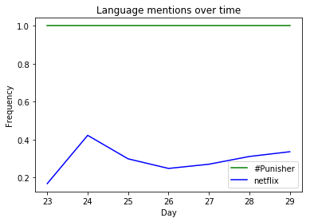

```python
# Plot mean python by day(green)/mean rstats by day(blue)
plt.plot(mean_punish.index.day, mean_punish, color = 'green')
plt.plot(mean_netflix.index.day, mean_netflix, color = 'blue')

# Add labels and show
plt.xlabel('Day'); plt.ylabel('Frequency')
plt.title('Language mentions over time')
plt.legend(('#Punisher', 'netflix'))
```